# Tour of HippoLinTools

## Function for plotting

The `HippoLinTools` package contains also some useful functions to plot data:

- `barPlotBeeswarm` : we used it earlier in the tutorial. It displays the data with each individual datapoint with the mean and the sem. You can either use it to diplay a single list of number (1) or to display a list of numbers according to another parameter (2)

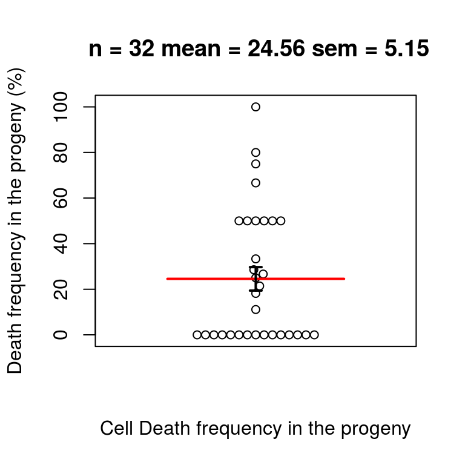

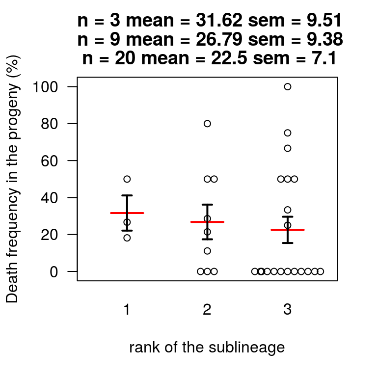

```r
# (1) Let's display the Cell death rate for each lineage
barPlotBeeswarm(myData = listCellDeathEarly$deathRate, xlab = "Cell Death frequency in the progeny", ylab = "Death frequency in the progeny (%)")

# (2) Let's display the Cell death rate for each lineage according to the rank of the sublineage
barPlotBeeswarm(myData = data.frame(listCellDeathEarly$deathRate, listCellDeathEarly$rank), xlab = "rank of the sublineage", ylab = "Death frequency in the progeny (%)")
```

- `add.alpha`: add transparency to a color

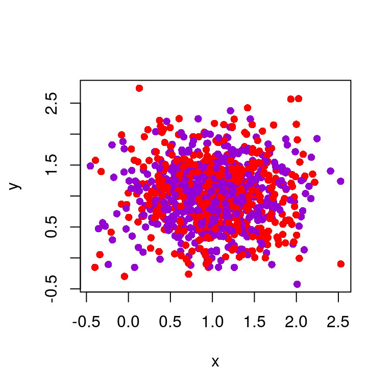

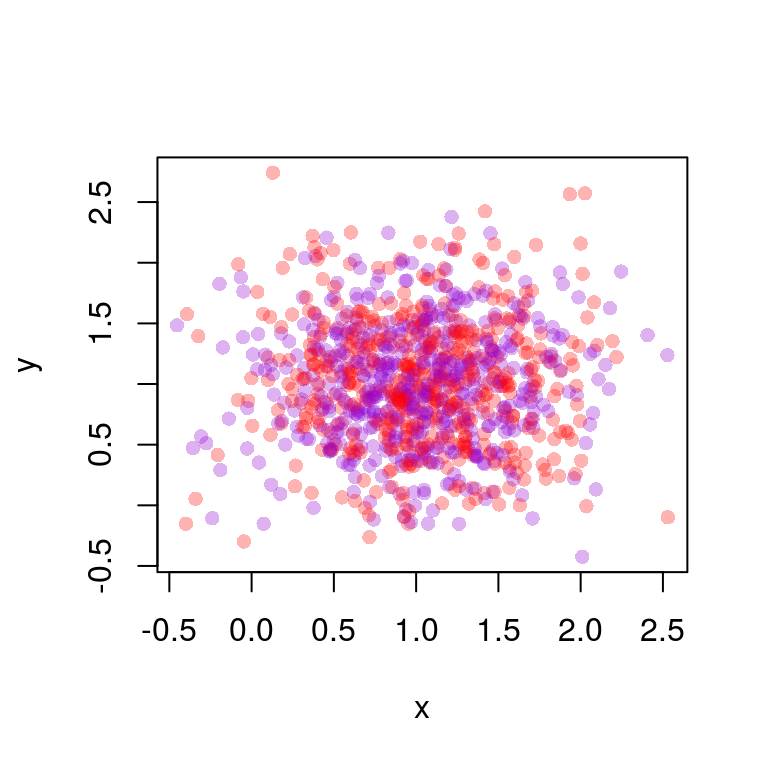

```r
# Let's define some random values for x and y (coming from a normal distribution)
x <- rnorm(1000, mean = 1, sd = 0.5)
y <- rnorm(1000, mean = 1, sd = 0.5)

# Let's define regular colors
colorX <- "red"
colorY <- colors()[115] # other way of defining colors
plot(x,y, col = c(colorX, colorY), pch = 16)

colorXalpha <- add.alpha(col = "red", alpha = 0.3)
colorYalpla <- add.alpha(colors()[115], 0.3)
plot(x,y, col = c(colorXalpha, colorYalpla), pch = 16)
```

- `error.bar` : function to add, oh surprise, error bars to a graph !

```r
# Let's define a vector
v1  <- c(1:4)
# Plot it in a barplot:
my.x <- barplot(v1, names.arg = c(1:4)) # notice that we save the non graphical outcome of the barplot in my.x
my.x                # my.X contains the x coordinates where the bars are plotted
```

```
##      [,1]
## [1,]  0.7
## [2,]  1.9
## [3,]  3.1
## [4,]  4.3
```

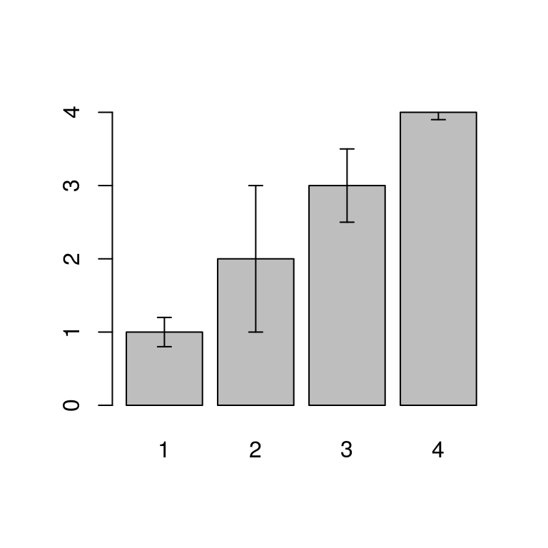

```r
# Let's define some errors for each value of v1
error <- c(0.2, 1, 0.5, 0.1)
# And add the error bars to the plot: one needs to define the x and y coordinates or each bar (x corresponds to my.x and y to v1), as well as the size of the error bar : error
error.bar(x = my.x, y = v1, upper = error)
```

### Useful ressources

- a great compilation of R Cheat Sheets! https://www.rstudio.com/resources/cheatsheets/ I would recommand *R Markdown Cheat Sheet*, *Data Visualization Cheat Sheet*
- for colors in R : for example http://www.sthda.com/english/wiki/colors-in-r